# Analysis of Project Split Story Usage and Patterns

### Introduction

**This report analyzes the project’s process patterns indicated by split user stories.**

Software development and maintenance projects that use an agile life-cycle, such as Scrum, document their requirements as ‘User Stories’. These stories are intended to describe a small software feature that is:  
1. Understandable to the customer/user,  
2. Can be implemented during one sprint (time-boxed delivery period), and  
3. Can be tested or demonstrated.

User stories that have not yet been implemented are maintained in a list called a ‘backlog’ and are subject to change as the customer/user needs change.

An **active** user story is a user story that is being implemented during the currently active sprint. Once a user story becomes active, it becomes a promise from the software developer to the customer/user to implement the user story and demonstrate it at the end of the sprint.

When a promise (active user story) cannot be delivered during the current sprint and the customer/user still wants the user story to be delivered, then the incomplete user story becomes a ‘split story’, that is, a deferred promise.

Split stories come in three varieties:

- **Summary split stories** where multiple previously incomplete stories are combined together into one story,
- **Clone split stories** where active but incomplete stories are re-designated with a new label and assigned to another (future) sprint,
- **Single split stories** where stories are partially completed during a sprint and the incomplete parts of the stories are assigned to another (future) sprint.

The existence of splits stories does not necessarily represent an issue for a project. For example,

- If agreed between the customer/user and the project, the project may plan to be aggressive in the user stories to which it commits. This aggressiveness will sometimes result in split stories.
- Due to circumstances outside its control, such as unplanned work interruptions, active user stories may not be completed during the promised sprint, resulting in split stories.

### How Split Stories Are Measured and Analyzed in this Report

There are four measurements that are collected with respect to the project’s split stories:

- The maximum number of split stories that the project should have during any sprint.
  - This measurement is called the ‘split story upper specification limit’ (USL) and is determined by agreement between customer/user and the project. This is sometimes called ‘the voice of the customer’.
  - Exceeding the split story USL indicates that, in the customer/user’s perspective, the project is unacceptably failing to keep its promises.
    - The project may have fewer split stories than the USL without repercussions.
- The minimum number of split stories that the project should have during any sprint.
  - This measurement is call the ‘split story lower specification limit’ (LSL) and is determined by agreement between the customer/user and the project. This is sometimes called ‘the voice of the customer’.
  - Falling below the split story LSL indicates that, in the customer/user’s perspective, the project is not being aggressive enough in planning for active stories during a sprint.
    - The split story LSL is typically not a ‘hard threshold’ measurement, since the project may sometimes be aggressive in planning and still fulfill all active user stories. The split story LSL might be used as an indicator for greater or lesser planning aggressiveness on the part of the project by the customer/user.
    - The minimum value for the split story LSL is zero.
    - The split story LSL is subject to artificial manipulation by a developer who might choose to ‘satisfy’ the metric by intentionally failing to complete a story.
- The maximum number of split stories the project should have *started* or *finished* during a sprint, based on the project’s past performance.
  - This measurement is call the ‘split story upper control limit’ (UCL) and is determined by statistically characterizing the project’s past performance. The split story UCL is sometimes called ‘the voice of the process’.
  - Exceeding the split story UCL for either split stories started or finished during a sprint indicates that the project is *deviating* from its typical performance. That is, the project’s process is discordant with ‘the voice of the process’ as historically demonstrated by the project.
  - Exceeding the split story UCL is a **strong** but **not an absolute** indicator of a process problem. For this report, the threshold used in the analysis was set so that exceeding the split story UCL is a **99%** chance indicator that a real process problem exists.
- The minimum number of split stories that the project should have *started* or *finished* during a sprint, based on the project’s part performance.
  - This measurement is call the ‘split story lower control limit’ (LCL) and is determined by statistically characterizing the project’s past performance. The split story LCL is sometimes called ‘the voice of the process’.
  - The split story LCL is *not* typically of interest for a project. It is not included in this report.

### Analysis Results

- The ellipses in the graph should be interpreted as follows:
  - The *vertical* ellipses represent out-of-bounds conditions for sprint starts (of the corresponding type). The associated labels identify which sprints violated the sprint start UCL threshold. In the analysis performed here, there is only a **1%** chance of the observed data representing the project’s expected behavior, given its historical performance.
  - Further investigation of what occurred in these sprints is **recommended**.
- The table below lists the data corresponding to these sprints for reference.

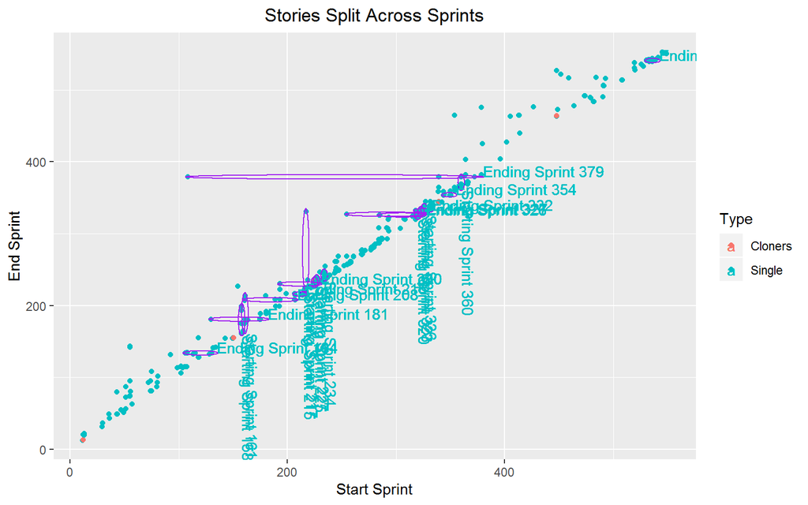

#### Single-Type Split Stories with Out-of-Bounds Conditions for Start Sprint

| First.Story.Key | Last.Story.Key | Subtask.Key | First.Sprint.Name | Last.Sprint.Name | First.Sprint.Id | Last.Sprint.Id | Summary |
| --- | --- | --- | --- | --- | --- | --- | --- |
| MESOS-2061 | NA | NA | Mesosphere Sprint 15 | Mesosphere Sprint 17 | 158 | 175 | NA |
| MESOS-2066 | NA | NA | Mesosphere Sprint 15 | Mesosphere Sprint 17 | 158 | 175 | NA |
| MESOS-2067 | NA | NA | Mesosphere Sprint 16 | Mesosphere Sprint 17 | 161 | 175 | NA |
| MESOS-2294 | NA | NA | Mesosphere Sprint 15 | Mesosphere Sprint 16 | 158 | 161 | NA |
| MESOS-2455 | NA | NA | Mesosphere Sprint 16 | Mesosphere Sprint 23 | 161 | 208 | NA |
| MESOS-2742 | NA | NA | Mesosphere Sprint 27 | Mesosphere Sprint 28 | 217 | 219 | NA |
| MESOS-2860 | NA | NA | Mesosphere Sprint 15 | Mesosphere Sprint 16 | 158 | 161 | NA |
| MESOS-2949 | NA | NA | Mesosphere Sprint 15 | Mesosphere Sprint 21 | 158 | 199 | NA |
| MESOS-3015 | NA | NA | Mesosphere Sprint 15 | Mesosphere Sprint 16 | 158 | 161 | NA |
| MESOS-3042 | NA | NA | Mesosphere Sprint 16 | Mesosphere Sprint 18 | 161 | 181 | NA |
| MESOS-3062 | NA | NA | Mesosphere Sprint 16 | Mesosphere Sprint 23 | 161 | 208 | NA |
| MESOS-3064 | NA | NA | Mesosphere Sprint 16 | Mesosphere Sprint 23 | 161 | 208 | NA |
| MESOS-3065 | NA | NA | Mesosphere Sprint 16 | Mesosphere Sprint 24 | 161 | 214 | NA |
| MESOS-3066 | NA | NA | Mesosphere Sprint 15 | Mesosphere Sprint 17 | 158 | 175 | NA |
| MESOS-3069 | NA | NA | Mesosphere Sprint 16 | Mesosphere Sprint 17 | 161 | 175 | NA |
| MESOS-3164 | NA | NA | Mesosphere Sprint 15 | Mesosphere Sprint 20 | 158 | 193 | NA |
| MESOS-3199 | NA | NA | Mesosphere Sprint 16 | Mesosphere Sprint 22 | 161 | 207 | NA |
| MESOS-3214 | NA | NA | Mesosphere Sprint 33 | Mesosphere Sprint 34 | 234 | 235 | NA |
| MESOS-3223 | NA | NA | Mesosphere Sprint 16 | Mesosphere Sprint 18 | 161 | 181 | NA |
| MESOS-3558 | NA | NA | Mesosphere Sprint 33 | Mesosphere Sprint 34 | 234 | 235 | NA |
| MESOS-3780 | NA | NA | Mesosphere Sprint 31 | Mesosphere Sprint 32 | 227 | 230 | NA |
| MESOS-3854 | NA | NA | Mesosphere Sprint 27 | Mesosphere Sprint 30 | 217 | 225 | NA |
| MESOS-3877 | NA | NA | Mesosphere Sprint 25 | Mesosphere Sprint 26 | 215 | 216 | NA |
| MESOS-4200 | NA | NA | Mesosphere Sprint 27 | Mesosphere Sprint 29 | 217 | 222 | NA |
| MESOS-4220 | NA | NA | Mesosphere Sprint 25 | Mesosphere Sprint 26 | 215 | 216 | NA |
| MESOS-4221 | NA | NA | Mesosphere Sprint 25 | Mesosphere Sprint 26 | 215 | 216 | NA |
| MESOS-4228 | NA | NA | Mesosphere Sprint 25 | Mesosphere Sprint 26 | 215 | 216 | NA |
| MESOS-4236 | NA | NA | Mesosphere Sprint 25 | Mesosphere Sprint 26 | 215 | 216 | NA |
| MESOS-4237 | NA | NA | Mesosphere Sprint 25 | Mesosphere Sprint 26 | 215 | 216 | NA |
| MESOS-4238 | NA | NA | Mesosphere Sprint 25 | Mesosphere Sprint 26 | 215 | 216 | NA |

[output cut: 70 more lines]

| First.Story.Key | Last.Story.Key | Subtask.Key | First.Sprint.Name | Last.Sprint.Name | First.Sprint.Id | Last.Sprint.Id | Summary |
| --- | --- | --- | --- | --- | --- | --- | --- |
| MESOS-2062 | NA | NA | Mesosphere Sprint 17 | Mesosphere Sprint 18 | 175 | 181 | NA |
| MESOS-2210 | NA | NA | Mesosphere Sprint 22 | Mesosphere Sprint 26 | 207 | 216 | NA |
| MESOS-2293 | NA | NA | Mesosphere Q1 Sprint 9 - 5/15 | Mesosphere Sprint 11 | 115 | 134 | NA |
| MESOS-2455 | NA | NA | Mesosphere Sprint 16 | Mesosphere Sprint 23 | 161 | 208 | NA |
| MESOS-2596 | NA | NA | Mesosphere Sprint 10 | Mesosphere Sprint 11 | 130 | 134 | NA |
| MESOS-2600 | NA | NA | Mesosphere Sprint 10 | Mesosphere Sprint 18 | 130 | 181 | NA |
| MESOS-2615 | NA | NA | Mesosphere Q1 Sprint 7 - 4/17 | Mesosphere Sprint 11 | 106 | 134 | NA |
| MESOS-2629 | NA | NA | Mesosphere Q2 Sprint 8 - 5/1 | Mesosphere Sprint 11 | 108 | 134 | NA |
| MESOS-2630 | NA | NA | Mesosphere Q2 Sprint 8 - 5/1 | Mesosphere Sprint 11 | 108 | 134 | NA |
| MESOS-2631 | NA | NA | Mesosphere Q2 Sprint 8 - 5/1 | Mesosphere Sprint 11 | 108 | 134 | NA |
| MESOS-2633 | NA | NA | Mesosphere Q2 Sprint 8 - 5/1 | Mesosphere Sprint 2018-25 | 108 | 379 | NA |
| MESOS-2650 | NA | NA | Mesosphere Sprint 10 | Mesosphere Sprint 11 | 130 | 134 | NA |
| MESOS-2651 | NA | NA | Mesosphere Sprint 10 | Mesosphere Sprint 11 | 130 | 134 | NA |
| MESOS-3038 | NA | NA | Mesosphere Sprint 17 | Mesosphere Sprint 18 | 175 | 181 | NA |
| MESOS-3042 | NA | NA | Mesosphere Sprint 16 | Mesosphere Sprint 18 | 161 | 181 | NA |
| MESOS-3043 | NA | NA | Mesosphere Sprint 17 | Mesosphere Sprint 18 | 175 | 181 | NA |
| MESOS-3062 | NA | NA | Mesosphere Sprint 16 | Mesosphere Sprint 23 | 161 | 208 | NA |
| MESOS-3063 | NA | NA | Mesosphere Sprint 20 | Mesosphere Sprint 32 | 193 | 230 | NA |
| MESOS-3064 | NA | NA | Mesosphere Sprint 16 | Mesosphere Sprint 23 | 161 | 208 | NA |
| MESOS-3223 | NA | NA | Mesosphere Sprint 16 | Mesosphere Sprint 18 | 161 | 181 | NA |
| MESOS-3265 | NA | NA | Mesosphere Sprint 17 | Mesosphere Sprint 18 | 175 | 181 | NA |
| MESOS-3266 | NA | NA | Mesosphere Sprint 17 | Mesosphere Sprint 18 | 175 | 181 | NA |
| MESOS-3476 | NA | NA | Mesosphere Sprint 20 | Mesosphere Sprint 23 | 193 | 208 | NA |
| MESOS-3515 | NA | NA | Mesosphere Sprint 19 | Mesosphere Sprint 23 | 189 | 208 | NA |
| MESOS-3780 | NA | NA | Mesosphere Sprint 31 | Mesosphere Sprint 32 | 227 | 230 | NA |
| MESOS-3857 | NA | NA | Mesosphere Sprint 22 | Mesosphere Sprint 23 | 207 | 208 | NA |
| MESOS-3877 | NA | NA | Mesosphere Sprint 25 | Mesosphere Sprint 26 | 215 | 216 | NA |
| MESOS-3911 | NA | NA | Mesosphere Sprint 22 | Mesosphere Sprint 23 | 207 | 208 | NA |
| MESOS-3912 | NA | NA | Mesosphere Sprint 22 | Mesosphere Sprint 23 | 207 | 208 | NA |
| MESOS-3925 | NA | NA | Mesosphere Sprint 24 | Mesosphere Sprint 26 | 214 | 216 | NA |

[output cut: 71 more lines]

### Next Steps

**Out-of-bounds conditions for sprint starts indicate that an unusual amount of work is being promised to a customer, while out-of-bounds conditions for sprint ends indicate that an unusual amount of work is finished during one sprint.**

- Using the graphs and tables above, determine all of the starting and ending sprints that had out-of-bounds conditions.
- Determine if the out-of-bounds conditions were caused by:
  - **Conditions outside the project’s control**, such as unexpected changes in staffing or customer-driven interruptions. If this was the case, use a *Failure Modes & Effects Analysis (FMEA)* to help the project identify, analyze, and manage surprises.
  - **Conditions within the project’s control**, such as not understanding the implications of multiple user stories (for instance, taking on user stories in areas where project personnel do not collectively have experience), changes in or deviations from a process, wrapping up a set of user stories that have accumulating and are ‘waiting’ for final completion, or adopting new tools. If this is the case, use root cause analysis tools such as *‘the five whys’* and *‘Ishikawa diagrams’* to identify and eliminate the root cause(s) of the condition.

### Analysis Model Verification

To be complete, the question of ‘How accurate is teh analysis described above?’ must be answered.  
The analysis uses the Poisson distribution to model the project’s split story behavior.  
The description and graphs shown below provide insight into the applicability of the Poisson distribution to each type of split with out-of-bounds conditions.  
The graphs are ‘Quantile-Quantile’ plots. If you are unfamiliar with this type of graphical analysis, refer to ‘Appendix A’ for interpretation information.

#### Cloners Split Story Starts Analysis Model Verification

Clone split stories are stories that are duplicated from a previously documented story and renamed with a new story identifier. The ‘Poisson Quantile-Quantile Plot for Clone Split Story Starts’ provides a graphical representation of the analysis for the number and frequency of Clone type split story starts.

- For points that fall within the confidence bands (vertical bars), the project’s Clone Type split stories are explained with 0.95% confidence by this analysis.
  - Points that are outside the bars mean that the project’s behavior is not typical but that the analysis is unable to explain this behavior.
  - If all of the points appear to fall in a straight line above or below the bands, then the project is systematically creating more (points above) or suppressing (points below) Clone type split stories. See ‘Appendix A’ for assistance in interpreting the patterns illustrated in the plot.
- **However, be cautious. There are too few Clone type split stories to conclusively characterize the project’s behavior.**

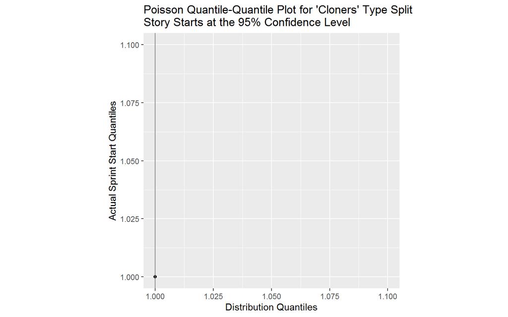

#### Cloners Split Story Finishes Analysis Model Verification

Clone split stories are stories that are duplicated from a previously documented story and renamed with a new story identifier. The ‘Poisson Quantile-Quantile Plot for Clone Split Story Finishes’ provides a graphical representation of the analysis for the number and frequency of Clone type split story finishes.

- For points that fall within the confidence bands (vertical bars), the project’s Clone Type split stories are explained with 0.95% confidence by this analysis.
  - Points that are outside the bars mean that the project’s behavior is not typical but that the analysis is unable to explain this behavior.
  - If all of the points appear to fall in a straight line above or below the bands, then the project is systematically creating more (points above) or suppressing (points below) Clone type split stories. See ‘Appendix A’ for assistance in interpreting the patterns illustrated in the plot.
- **However, be cautious. There are too few Clone type split stories to conclusively characterize the project’s behavior.**

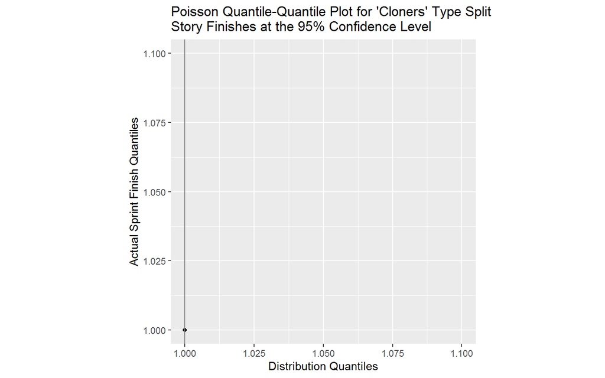

#### Single Split Story Starts Analysis Model Verification

Single split stories are stories that are being actively worked for deliver in the current sprint, are only partially completed, and then the remaining work is moved into a future sprint. The ‘Poisson Quantile-Quantile Plot for Single Split Story Starts’ provides a graphical representation of the analysis for the number and frequency of Single type split story starts.

- For points that fall within the confidence bands (vertical bars), the project’s Single Type split stories are explained with 0.95% confidence by this analysis.
  - Points that are outside the bars mean that the project’s behavior is not typical but that the analysis is unable to explain this behavior.
  - If all of the points appear to fall in a straight line above or below the bands, then the project is systematically creating more (points above) or suppressing (points below) Single type split stories. See ‘Appendix A’ for assistance in interpreting the patterns illustrated in the plot.
- **Note that there *is* enough total data to generally characterize the project’s behavior with Single type split stories.**

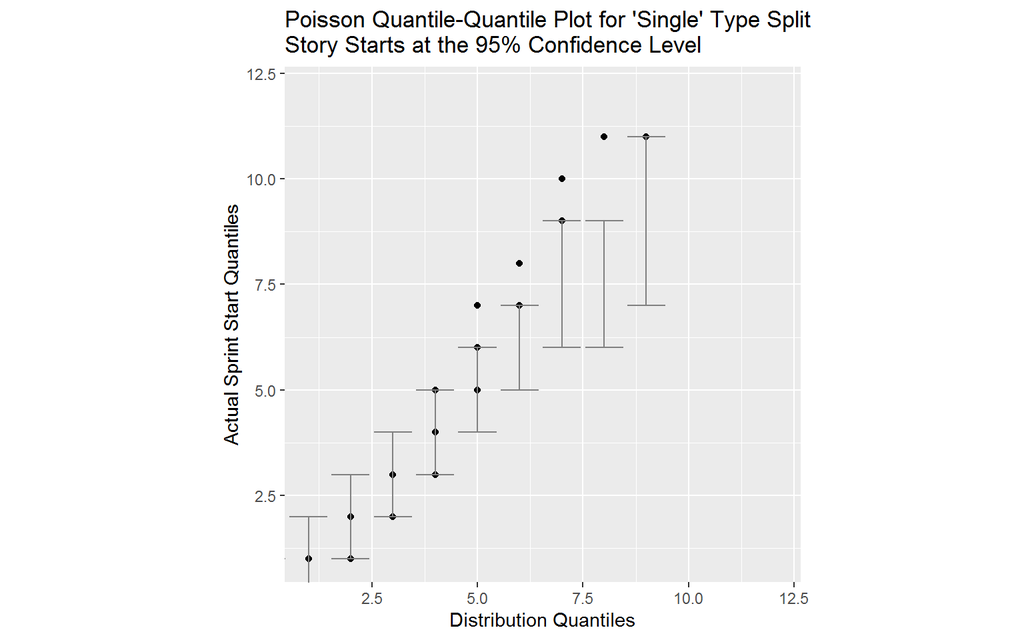

#### Single Split Story Finishes Analysis Model Verification

Single split stories are stories that are being actively worked for deliver in the current sprint, are only partially completed, and then the remaining work is moved into a future sprint. The ‘Poisson Quantile-Quantile Plot for Single Split Story Finishes’ provides a graphical representation of the analysis for the number and frequency of Single type split story finishes

- For points that fall within the confidence bands (vertical bars), the project’s Single Type split stories are explained with 0.95% confidence by this analysis.
  - Points that are outside the bars mean that the project’s behavior is not typical but that the analysis is unable to explain this behavior.
  - If all of the points appear to fall in a straight line above or below the bands, then the project is systematically creating more (points above) or suppressing (points below) Single type split stories. See ‘Appendix A’ for assistance in interpreting the patterns illustrated in the plot.
- **Note that there *is* enough total data to generally characterize the project’s behavior with Single type split stories.**

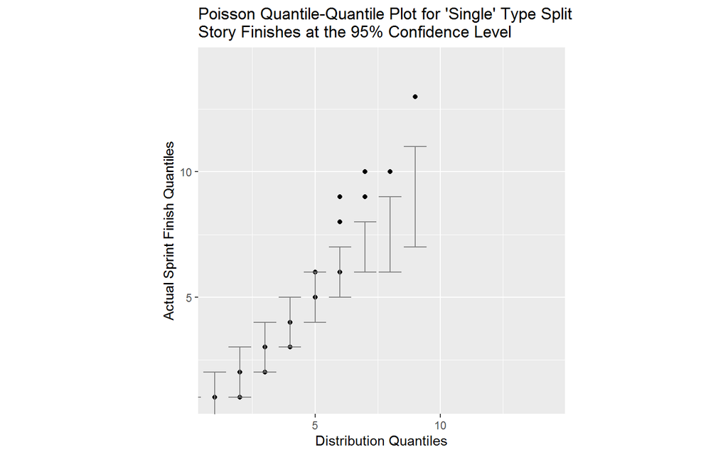

### Appendix A: Interpretation of Q-Q Plots

The patterns shown in Q-Q plots show how well the actual data being observed corresponds to the theoretical model used in the analysis. Different shapes indicate deviations between the observations and the theoretical model, which might result in the analysis being conservative (that is, failing to identify real problems) or liberal (that is, imagining problems that do not exist).  
The following Q-Q Plot diagnostic is provided courtesy of the SAS Institute, Inc.

| Description of Point Pattern | Possible Interpretation |
| --- | --- |
| All points fall in the bands | Theoretical model is a useful analysis for the observed data |
| All but a few points fall in the bands | Outliers in the data |
| The left end of the pattern falls below the bands; the right end falls above the bands | ‘Long tails’ at both ends of the observed data: under-estimated analysis |
| The left end of the pattern falls above the bands; the right end falls below the bands | ‘Short tails’ at both ends of the observed data: over-estimated analysis |
| Curved pattern with slope increasing from left to right | Observed data is right-skewed: over-estimated analysis |
| Curved pattern with slope decreasing from left to right | Observed data is left-skewed: under-estimated analysis |

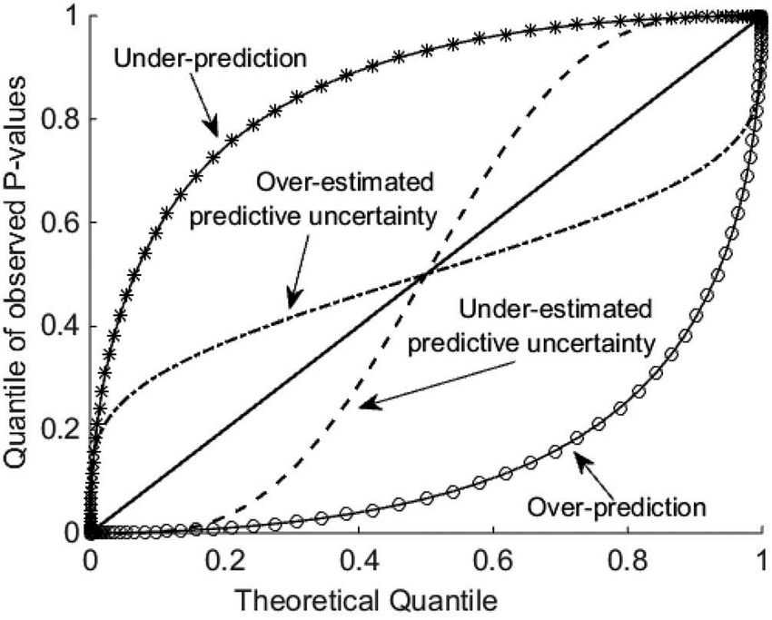